# TPE1_GARCIAPALACIO

[figure not shown]

# ESPECIALIZACIÓN EN MÉTODOS CUANTITATIVOS PARA LA GESTIÓN Y ANÁLISIS DE DATOS EN ORGANIZACIONES

# E72V 07 TALLER DE PROGRAMACIÓN

# PRIMERA INSTANCIA DE EVALUACIÓN

### DOCENTE: : Rodrigo Del Rosso-Patricia Girimonte

### ESTUDIANTE: Florencia Gracía Palacio

### 2022

# Introducción

El presente trabajo es realizado para la materia “Taller de Programación” de la “Maestría en métodos cuantitativos para la gestión y análisis de datos en las organizaciones” de la UBA.

El objetivo principal será se elaborar un análisis multivariado, aplicando los conocimientos obtenidos durante el cursado del taller. Se tomará como base el dataset de cursos de Udemy obtenido en la plataforma kaggle, que se puede encontrar en el siguiente [Link](https://www.kaggle.com/datasets/thedevastator/udemy-courses-revenue-generation-and-course-anal?resource=download), en el cual se presenta un problema de regresión donde el objetivo principal es determinar el precio que deberá tener un curso, en base a varias características. Es por esto que se realizará un EDA con foco principal en la variable precio y su relación con otras variables.

| Nombre de Columna | Descripción |
| --- | --- |
| course_title | Título del curso. (String) |
| url | URL del curso (String) |
| price | Precio del curso (Float) |
| num_subscribers | Número de personas inscriptas en el curso. (Integer) |
| num_reviews | Número de reviews que recibió el curso. (Integer) |
| num_lectures | Cantidad de clases que tiene el curso (Integer) |
| level | Nivel del curso. (String) |
| content_duration | Duración del curso. (Float) |
| published_timestamp | Fecha y hora en la que el curso se publicó. (Datetime) |
| subject | Tema del curso (String) |

A modo de ejemplo se presentan las dos primeras filas de la base de datos seleccionada:

| course_id | course_title | url | price | num_subscribers | num_reviews | num_lectures | level | Rating | content_duration | published_timestamp | subject |
| --- | --- | --- | --- | --- | --- | --- | --- | --- | --- | --- | --- |
| 49798 | Bitcoin or How I Learned to Stop Worrying and Love Crypto | https://www.udemy.com/bitcoin-or-how-i-learned-to-stop-worrying-and-love-crypto/ | 0 | 65576 | 936 | 24 | All Levels | 0.56 | 8.0 | 2013-04-20T02:25:22Z | Business Finance |
| 48841 | Accounting in 60 Minutes - A Brief Introduction | https://www.udemy.com/accounting-in-60-minutes-a-brief-introduction/ | 0 | 56659 | 4397 | 16 | Beginner Level | 0.95 | 1.5 | 2013-04-07T21:39:25Z | Business Finance |

# Análisis

## Limpieza de datos

Antes de comenzar con el análisis de los datos, es importante corroborar que los mismos esten en óptimas condiciones para ser analizados, esto con tal de asegurar que las conclusiones que obtengamos sean válidas. Con tal fin se constató la presencia de valores nulos y duplicados.

### Valores nulos

Se encontraron valores nulos en el dataset. También se observó que en algunas variables, si bien no había valores nulos, teníamos columnas categóricas con textos vacios o espacios, los cuales son equivalentes a valores nulos. Se decidió borrarlos, ya que todos los valores pertenecían a las mismas filas y probablemente son errores en la carga o el proceso de los archivos. A modo de resumen se presenta la cantidad de valores nulos en cada columna:

|  | cantidad_NULL |
| --- | --- |
| course_id | 5 |
| price | 5 |
| num_subscribers | 5 |
| num_reviews | 5 |
| num_lectures | 5 |
| Rating | 4 |
| content_duration | 5 |

### Duplicados

Se encontraron valores duplicados, se decidió borrarlos, ya que no representaban un porcentaje significativo de la base y no podíamos salvar los errores que pudieran derivarse de tenerlos en cuenta para el análisis de la variable rating.

A continuación se presenta el detalle de los IDs duplicados:

| course_id | course_title | url | price | num_subscribers | num_reviews | num_lectures | level | Rating | content_duration | published_timestamp | subject |
| --- | --- | --- | --- | --- | --- | --- | --- | --- | --- | --- | --- |
| 142666 | Improved SEO with Rich Snippets and MicroData | https://www.udemy.com/improved-seo-with-rich-snippets-and-microdata/ | 0 | 11026 | 228 | 13 | Beginner Level | 0.80 | 1.0 | 2014-06-09T10:35:40Z | Subject: Web Development |
| 142666 | Improved SEO with Rich Snippets and MicroData | https://www.udemy.com/improved-seo-with-rich-snippets-and-microdata/ | 0 | 11026 | 228 | 13 | Beginner Level | 0.92 | 1.0 | 2014-06-09T10:35:40Z | Subject: Web Development |
| 241590 | Make a professional website - 30 Day Guarantee. Discounted! | https://www.udemy.com/make-your-own-business-website-beginner-and-intermediate/ | 20 | 11167 | 34 | 13 | Beginner Level | 0.68 | 2.0 | 2014-06-23T16:03:41Z | Subject: Web Development |
| 241590 | Make a professional website - 30 Day Guarantee. Discounted! | https://www.udemy.com/make-your-own-business-website-beginner-and-intermediate/ | 20 | 11167 | 34 | 13 | Beginner Level | 0.92 | 2.0 | 2014-06-23T16:03:41Z | Subject: Web Development |
| 736940 | Practical CSS Website Development: Crash Course | https://www.udemy.com/css-website-development-crash-course/ | 95 | 11170 | 35 | 19 | Beginner Level | 0.11 | 2.5 | 2016-02-02T21:05:27Z | Subject: Web Development |
| 736940 | Practical CSS Website Development: Crash Course | https://www.udemy.com/css-website-development-crash-course/ | 95 | 11170 | 35 | 19 | Beginner Level | 0.92 | 2.5 | 2016-02-02T21:05:27Z | Subject: Web Development |

## Análisis Univariado: Distribución de las variables

A continuación se estudiará la distribución de las variables bajo análisis, para entender el comportamiento que presenta cada una individualmente y sus principales medidas resumen.

Resumen de las principales medidas descriptivas:

| precio | duración | Rating | Tema | Nivel |
| --- | --- | --- | --- | --- |
| Min. : 0.00 | Min. : 0.000 | Min. :0.0000 | Length:3668 | Length:3668 |
| 1st Qu.: 20.00 | 1st Qu.: 1.000 | 1st Qu.:0.2800 | Class :character | Class :character |
| Median : 45.00 | Median : 2.000 | Median :0.7600 | Mode :character | Mode :character |
| Mean : 66.09 | Mean : 4.099 | Mean :0.6107 |  |  |
| 3rd Qu.: 95.00 | 3rd Qu.: 4.500 | 3rd Qu.:0.9300 |  |  |
| Max. :200.00 | Max. :78.500 | Max. :1.0000 |  |  |

La distribución de las variables no es normal. Nuestra variable principal precio esta concentrada principalmente en valores bajos, pero podemos observar que hay un grupo de cursos que se encuentra en torno a los 200usd.

La mayoria de los cursos son de finanzas y web development y de Todos los niveles.

En los siguientes gráficos de densidad y frecuencia podremos observar el comportamiento de cada variable:

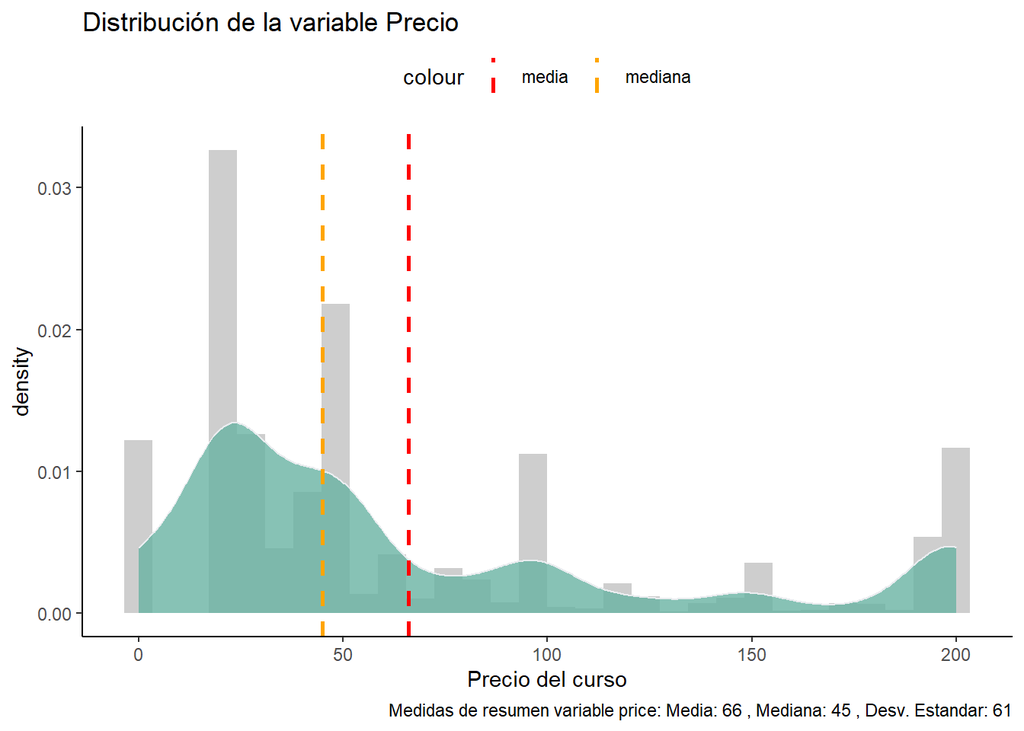

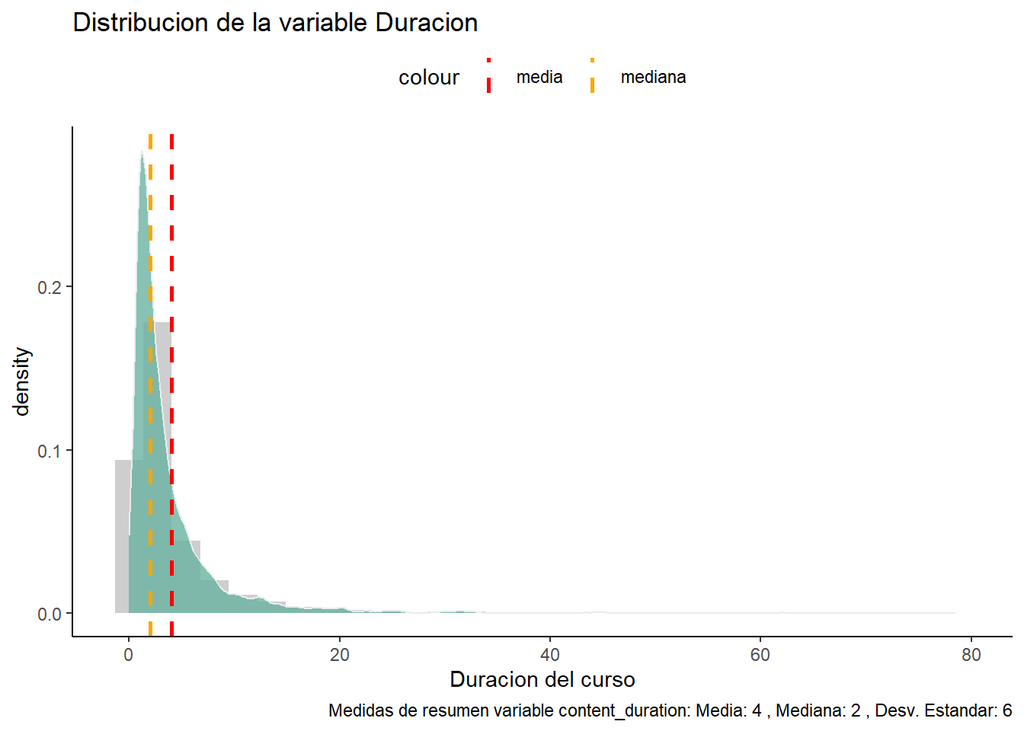

[figure not shown]

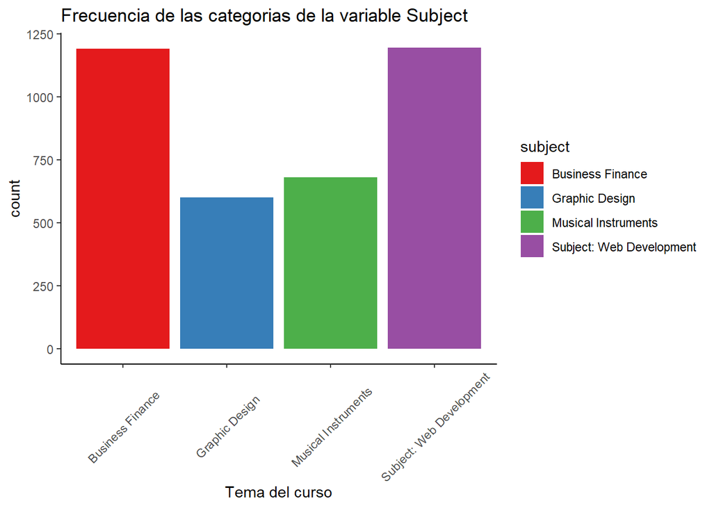

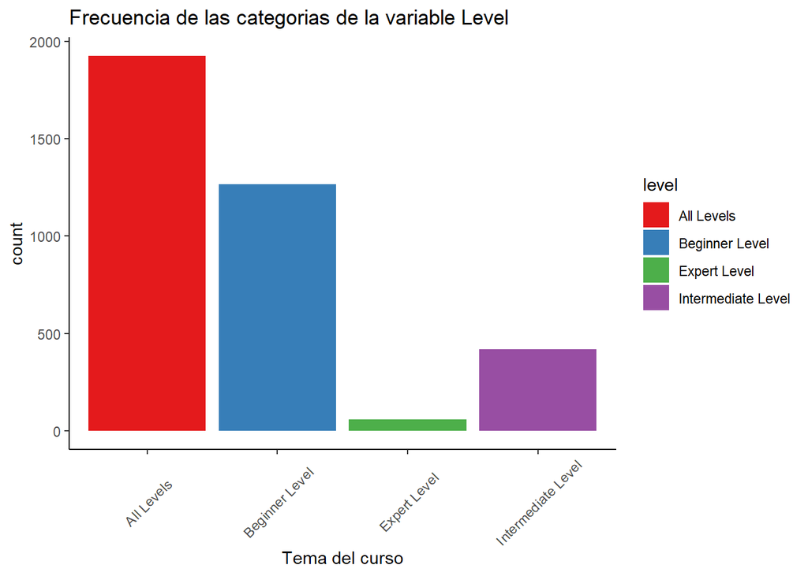

## Análisis multivariado

A continuación se evaluará la relación entre las variables, para determinar si existen relaciones significativas entre cada una de ellas y el precio

## Variables numéricas

No se encontro evidencia de relación lineal significativa entre las variables numéricas analizadas y la variable precio. Como se puede evidenciar en los siguientes gráficos:

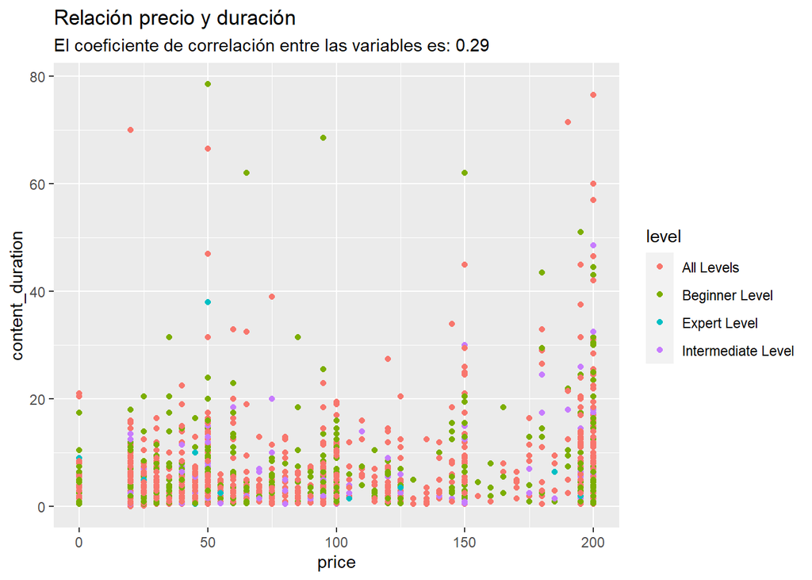

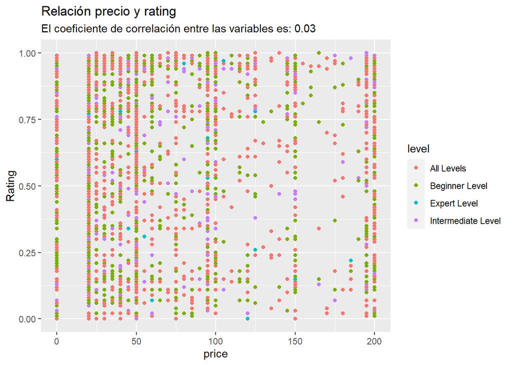

## Variables Categóricas

Al observar la variable precio en relación con el nivel del curso y con el tema principal del mismo, se puede evidenciar que existen diferencias de precio según estas categorias.

Al comparar los precios de los distintos niveles, podemos ver que sus distribuciones son similares con medianas en torno a los 45usd en la mayoría de los casos. Si bien la mayoría de los cursos se concentran en precios bajos, podemos apreciar que:

- All Levels y begginers levels son los más similares en comportamiento.
- Expert Level tiene menor media y mediana, con menos densidad en cursos de los precios más altos.

| level | media_precio | mediana_precio |
| --- | --- | --- |
| All Levels | 66.75 | 45.0 |
| Beginner Level | 65.37 | 45.0 |
| Expert Level | 58.02 | 42.5 |
| Intermediate Level | 66.33 | 45.0 |

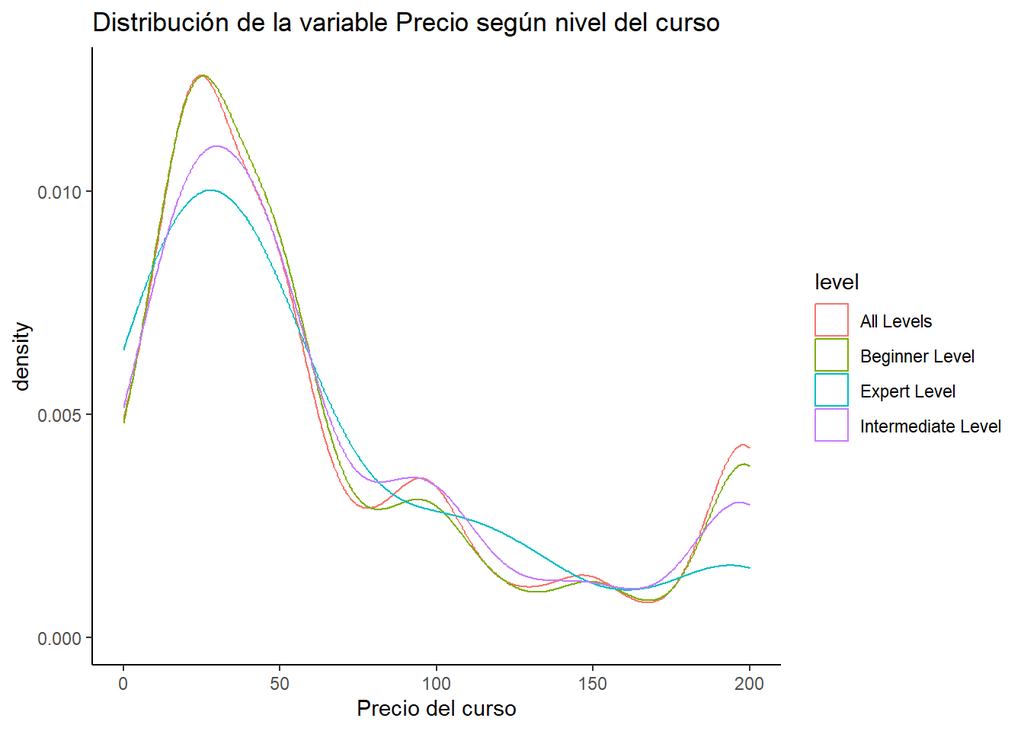

Al ver la variable precio en relación al tema del curso vemos diferencias significativas entre las medias y medianas. Además, sus distribuciones son diferentes.

| subject | media_precio | mediana_precio |
| --- | --- | --- |
| Business Finance | 68.69 | 45 |
| Graphic Design | 57.89 | 30 |
| Musical Instruments | 49.56 | 40 |
| Subject: Web Development | 77.03 | 50 |

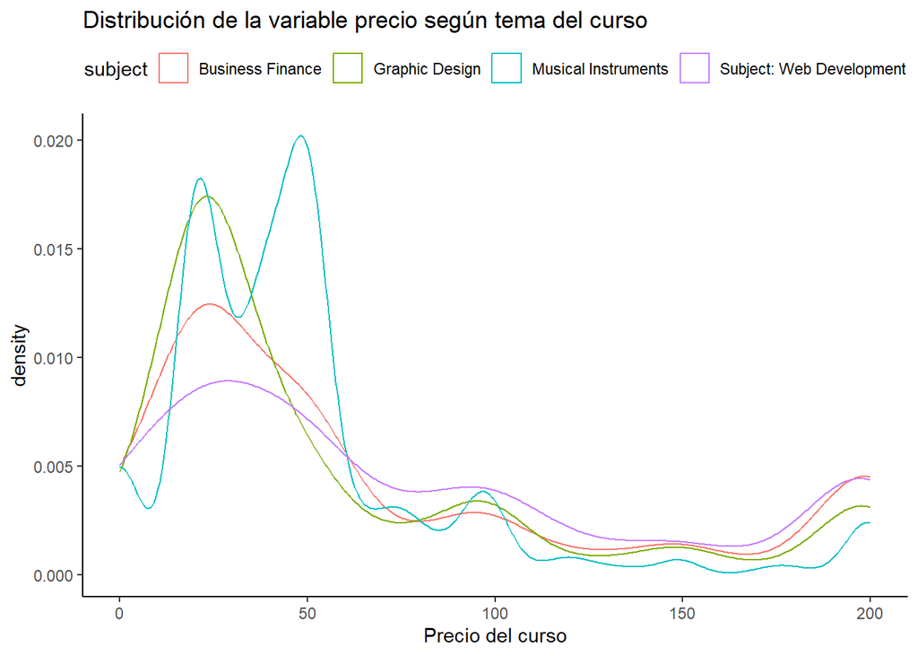

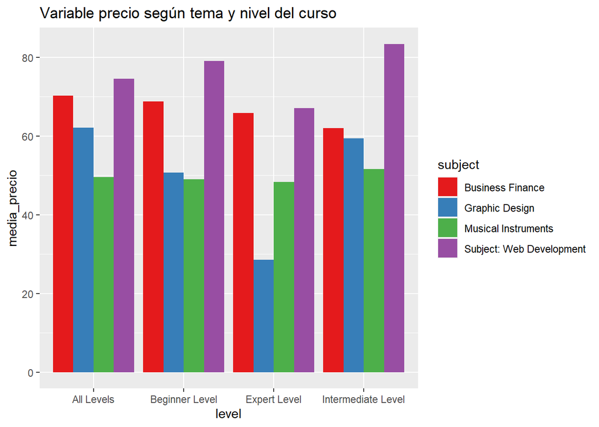

# Conclusiones

En base al análisis realizado podemos concluir que el precio de los cursos de Udemy dependera en principal medida del tema principal del que trate, siendo Web Development la categoría donde se encuentran los precios más altos. En menor medida el precio también se ve influenciado por el nivel al que pertenezca el curso, salvo para los cursos de Musical Instruments donde el precio de todos los niveles es similar. Por otro lado, podemos decir que el precio no esta linealmente relacionado con los ratings que las personas dan a los cursos, ni con su duración.